# ChestXray_EncoderDecoder

```python
import tensorflow as tf
import pandas as pd
import numpy as np
import random as rn
import math
from PIL import Image, ImageDraw
from PIL import ImagePath
from skimage.transform import resize
from numpy import array
from numpy import asarray
from numpy import zeros
from tensorflow.keras.applications.densenet import DenseNet121
from tensorflow.keras.applications.densenet import preprocess_input
from keras.preprocessing.text import one_hot
from keras.preprocessing.text import Tokenizer
from keras.preprocessing.sequence import pad_sequences
from sklearn.model_selection import train_test_split
from tensorflow.keras.models import Model
from tensorflow.keras.layers import Dense, LSTM, Input, Embedding, Conv2D, Concatenate, Flatten, Add, Dropout
from nltk.translate.bleu_score import sentence_bleu
import random
import pickle
import os
from tqdm import tqdm
```

```python
from google.colab import drive
drive.mount('/content/drive')
%cd /content/drive
```

```
/content/drive
```

**Data Loading**

```python
final_data = pd.read_csv('/content/drive/My Drive/CS2/final.csv')
final_data.drop(final_data.columns[0], axis=1, inplace=True)
final_data.head(5)
```

|  | Frontal | Lateral | Findings |
| --- | --- | --- | --- |
| 0 | CXR567_IM-2167-1001 | CXR567_IM-2167-2001 | heart size upper normal but stable mediastinal... |
| 1 | CXR516_IM-2130-1001 | CXR516_IM-2130-2001 | normal heart calcified right hilar granulomas ... |
| 2 | CXR519_IM-2131-1001 | CXR519_IM-2131-2001 | no pneumothora pleural effusion or airspace co... |
| 3 | CXR519_IM-2131-1001 | CXR519_IM-2131-4001 | no pneumothora pleural effusion or airspace co... |
| 4 | CXR519_IM-2131-2001 | CXR519_IM-2131-4001 | no pneumothora pleural effusion or airspace co... |

```python
def appendStartEnd(report):
  return 'start'+' '+report+' '+'end'
```

```python
final_data['Findings']=final_data['Findings'].apply(appendStartEnd)
final_data.head(5)
```

|  | Frontal | Lateral | Findings |
| --- | --- | --- | --- |
| 0 | CXR567_IM-2167-1001 | CXR567_IM-2167-2001 | start heart size upper normal but stable media... |
| 1 | CXR516_IM-2130-1001 | CXR516_IM-2130-2001 | start normal heart calcified right hilar granu... |
| 2 | CXR519_IM-2131-1001 | CXR519_IM-2131-2001 | start no pneumothora pleural effusion or airsp... |
| 3 | CXR519_IM-2131-1001 | CXR519_IM-2131-4001 | start no pneumothora pleural effusion or airsp... |
| 4 | CXR519_IM-2131-2001 | CXR519_IM-2131-4001 | start no pneumothora pleural effusion or airsp... |

Added "start" and "end" words to all findings.

"Start" word will kick-off the generation process and "end" word signal the end of the report

**Train Test Split**

```python
y = final_data["Findings"]
X = final_data.drop(columns=['Findings'],axis=0)
X_train, X_tcv, y_train, y_tcv = train_test_split(X, y, test_size=0.25, random_state=42)
X_cv, X_test, y_cv, y_test = train_test_split(X_tcv, y_tcv, test_size=0.40, random_state=42)
X_train.shape,X_cv.shape,X_test.shape
```

```
((2787, 2), (557, 2), (372, 2))
```

**Converting Findings into vector**

```python
token = Tokenizer()

token.fit_on_texts(y.values)
vocab_size = len(token.word_index) + 1
#text_to_sequence method will convert report into vector
encoded_findings_train = token.texts_to_sequences(y.values)
max_length = np.max([len(li) for li in encoded_findings_train])
print(vocab_size,max_length)
```

```
1663 167
```

Tokenization is a way of separating a piece of text into smaller units called tokens. Tokens can be either words or characters but in our case it’ll be words.

```python
embeddings_index = dict()
f = open('/content/drive/My Drive/CS2/glove.6B.100d.txt')
for line in f:
	values = line.split()
	word = values[0]
	coefs = asarray(values[1:], dtype='float32')
	embeddings_index[word] = coefs
f.close()

#Weight Matrix we will use this weights in embedding layer
embedding_matrix = zeros((vocab_size, 100))
for word, i in token.word_index.items():
	embedding_vector = embeddings_index.get(word)
	if embedding_vector is not None:
		embedding_matrix[i] = embedding_vector
```

**Conveting Image into vector**

DESNET-121

```python
#Desnet121 trained on xray iamges which is 242 layer network.
model = DenseNet121(weights = '/content/drive/My Drive/CS2/brucechou1983_CheXNet_Keras_0.3.0_weights.h5',   input_shape=(224,224,3), classes=14,pooling="avg")
input = model.input
#Removed last three layers. output tensor (None,1024)
output = model.layers[-2].output
model_features = Model(input, output)
```

```python
def preProcessImage(img_name):
  img_name = '/content/drive/My Drive/CS2/Data-cs2/NLMCXR_png/'+img_name+'.png'
  #Load image from a file
  image = Image.open(img_name)
  #Convert image into RGB image
  rgb_image = image.convert("RGB")
  #Covert PIL image into numpy array to get the value of each pixel
  pil_array = np.asarray(rgb_image)
  #Centered image to the format the model requires
  pre_process = preprocess_input(pil_array)
  #resizing image to fixed sixe
  re_size = resize(pre_process, (224,224,3))
  #Expands shape of array here it is (1,224,224,3)
  final_image= np.expand_dims(re_size, axis=0)
  return final_image
```

```python
def covertImageIntovector(dataset):
  features_vector = []
  for frontal , lateral in tqdm(dataset.values,position=0,leave=True):
    #converting images into vector. [tensor shape (1,1024)]
    frontal_vector =  model_features.predict(preProcessImage(frontal))
    lateral_vector =  model_features.predict(preProcessImage(lateral))
    #Concatenate vectors of both images. [tensor shape (1,2048)]
    concat = np.concatenate((frontal_vector,lateral_vector),axis=1)
    #final_conc = np.reshape(concat, concat.shape[1])
    features_vector.append(concat)
  return features_vector
```

```python
train_data_images = covertImageIntovector(X_train)
cv_data_images = covertImageIntovector(X_cv)
test_data_images = covertImageIntovector(X_test)
```

**Saving both images and reports into Pickle files**

```python
features ={}
features['image_train']=train_data_images
features['image_cv']=cv_data_images
features['image_test']=test_data_images
features['y_train']=y_train.values
features['y_cv']=y_cv.values
features['y_test']=y_test.values

file = open('/content/drive/My Drive/CS2/features_enc_2048.pickle','wb')
pickle.dump(features, file)
file.close()
```

```python
file = open('/content/drive/My Drive/CS2/features_enc_2048.pickle','rb')
features = pickle.load(file)
file.close()
```

**Input - Output Pairs**

```python
def createInputOutputPairs(images,report):
  input_pair=[]
  output_pair=[]
  image_pair=[]
  #Converting findings into vector
  report_vector = [token.word_index[word] for word in report.split() if word in token.word_index.keys()]
  for index in range(len(images)):
    for vec in range(1,len(report_vector)):
      #input sequnce
      input = report_vector[:vec]
      #output word for inout sequence
      output = report_vector[vec]
      #post padding on input : size of vector 167
      input_pad = pad_sequences([input],maxlen=max_length,padding='post')[0]
      #converting output word into categorical val : size of vector is vocab size(1545)
      output_cat = tf.keras.utils.to_categorical([output], num_classes=vocab_size)[0]
      input_pair.append(input_pad)
      output_pair.append(output_cat)
      image_pair.append(images[index])

  return np.array(image_pair),np.array(input_pair),np.array(output_pair)
```

**Dataset Creation**

```python
"""class Dataset:

  def __init__(self,images,reports,batch_size=1, shuffle=False):
    self.images_vec = images
    self.reports_str = reports
    self.batch_size = batch_size
    self.shuffle = shuffle
    self.indexes = np.arange(len(images))

  def __getitem__(self, i):
    start = i * self.batch_size
    stop = (i + 1) * self.batch_size
    image_batch=[]
    input_batch = []
    output_batch = []
    for val in range(start , stop):
      images_2,input,output = createInputOutputPairs(self.images_vec[i],self.reports_str[i])
      image_batch.append(images_2)
      input_batch.append(input)
      output_batch.append(output)

    return image_batch,input_batch,output_batch

  def __len__(self):
    return len(self.indexes) // self.batch_size

  def on_epoch_end(self):
    if self.shuffle:
      self.indexes = np.random.permutation(self.indexes)"""
```

```python
"""train_dataset = Dataset(features['image_train'],features['y_train'],batch_size=16,shuffle=True)
cv_dataset = Dataset(features['image_cv'],features['y_cv'],batch_size=16,shuffle=True)
test_dataset = Dataset(features['image_test'],features['y_test'],batch_size=16,shuffle=True)"""
```

```python
def create_dataset(image_vector, report_str):
  dataset = tf.data.Dataset.from_tensor_slices((image_vector, report_str))
  dataset = dataset.shuffle(300).batch(16).prefetch(buffer_size=tf.data.experimental.AUTOTUNE)
  return dataset
```

```python
train_dataset = create_dataset(train_data_images,y_train.values)
cv_dataset = create_dataset(cv_data_images,y_cv.values)
test_dataset = create_dataset(test_data_images,y_test.values)
```

```python
def convertToString(report):
  for index in range(len(report)):
    report[index] = report[index].decode('utf-8')
  return ' '.join(str(word) for word in report)
```

**Encoder & Decoder Model**

```python
os.environ['PYTHONHASHSEED'] = '0'

tf.keras.backend.clear_session()

#random seed values to regenerate the model.
np.random.seed(0)
rn.seed(0)

#Image input Layer
input_image = Input(shape=(2048,), name='Image')
dense_image = Dense(256, kernel_initializer=tf.keras.initializers.glorot_uniform, name='dense_image')(input_image)

#Text input layer
input_text = Input(shape=(167,), name='Text')
Embedding_layer = Embedding(input_dim = vocab_size, output_dim = 100, input_length=167, mask_zero=True, trainable=False,
                weights=[embedding_matrix], name="Embedding_layer")
emb_layer = Embedding_layer(input_text)

#LSTM layer
lstm_layer = LSTM(units=256, activation='tanh', recurrent_activation='sigmoid', use_bias=True,kernel_initializer=tf.keras.initializers.glorot_uniform,recurrent_initializer=tf.keras.initializers.orthogonal,
            bias_initializer=tf.keras.initializers.zeros(), return_sequences=True, name="lstm_layer")(emb_layer)

lstm_layer_1 = LSTM(units=256, activation='tanh', recurrent_activation='sigmoid', use_bias=True,kernel_initializer=tf.keras.initializers.glorot_uniform,recurrent_initializer=tf.keras.initializers.orthogonal,
            bias_initializer=tf.keras.initializers.zeros(), name="lstm_layer_1")
lstm_layer_1_output = lstm_layer_1(lstm_layer)
#Droput
dropout_layer = Dropout(0.4, name='dropout_layer')(lstm_layer_1_output)

add_layer =  tf.keras.layers.Add()([dense_image, dropout_layer])

#Fully connected layer
fully_connected = Dense(256, activation='relu', kernel_initializer=tf.keras.initializers.he_normal, name='fully_connected')
fc1_output = fully_connected(add_layer)

dropout_layer_1 = Dropout(0.3, name='dropout_layer_1')(fc1_output)
output_layer = Dense(vocab_size, activation='softmax', name='Output_layer')
output = output_layer(dropout_layer_1)

#Final Model
encoder_decoder = Model(inputs = [input_image, input_text], outputs = output)
encoder_decoder.summary()
```

```
Model: "model"
__________________________________________________________________________________________________
Layer (type)                    Output Shape         Param #     Connected to
==================================================================================================
Text (InputLayer)               [(None, 167)]        0
__________________________________________________________________________________________________
Embedding_layer (Embedding)     (None, 167, 100)     166300      Text[0][0]
__________________________________________________________________________________________________
lstm_layer (LSTM)               (None, 167, 256)     365568      Embedding_layer[0][0]
__________________________________________________________________________________________________
Image (InputLayer)              [(None, 2048)]       0
__________________________________________________________________________________________________
lstm_layer_1 (LSTM)             (None, 256)          525312      lstm_layer[0][0]
__________________________________________________________________________________________________
dense_image (Dense)             (None, 256)          524544      Image[0][0]
__________________________________________________________________________________________________
dropout_layer (Dropout)         (None, 256)          0           lstm_layer_1[0][0]
__________________________________________________________________________________________________
add (Add)                       (None, 256)          0           dense_image[0][0]
                                                                 dropout_layer[0][0]
__________________________________________________________________________________________________
fully_connected (Dense)         (None, 256)          65792       add[0][0]
__________________________________________________________________________________________________
dropout_layer_1 (Dropout)       (None, 256)          0           fully_connected[0][0]
__________________________________________________________________________________________________
Output_layer (Dense)            (None, 1663)         427391      dropout_layer_1[0][0]
==================================================================================================
Total params: 2,074,907
Trainable params: 1,908,607
Non-trainable params: 166,300
__________________________________________________________________________________________________
```

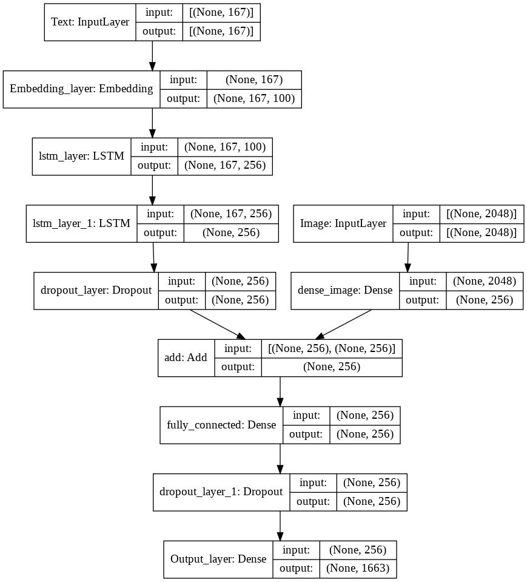

```python
from tensorflow import keras
keras.utils.plot_model(encoder_decoder, "/content/drive/My Drive/CS2/Encoder-Decoder.png", show_shapes=True)
```

**Loss Function**

```python
crossentropy = tf.keras.losses.CategoricalCrossentropy(from_logits=False, reduction='auto')

def loss_function(y_true, y_pred):
  #Find mask tokens so that we can ignore them while calculating loss
  mask_token = tf.math.logical_not(tf.math.equal(y_true, 0))
  #calculating the loss
  loss = crossentropy(y_true, y_pred)
  #Converting True anf False values into 1's and 0's
  mask_token = tf.cast(mask_token, dtype=loss.dtype)
  loss = loss*mask_token
  #Mean over all the values
  loss = tf.reduce_mean(loss)
  return loss
```

**Compiling Model**

```python
encoder_decoder.compile(tf.keras.optimizers.Adam(0.001), loss = loss_function)
```

**Logs**

```python
summary_train = tf.summary.create_file_writer('/content/drive/My Drive/CS2/trainLogs_15e_1')
summary_cv = tf.summary.create_file_writer('/content/drive/My Drive/CS2/cvLogs_15e_1')
```

```python
%load_ext tensorboard
```

**Model Training**

```python
for epoch in range(15):
  train_batch_loss = 0
  cv_batch_loss = 0

  for image, report  in train_dataset:
    str_report = convertToString(report.numpy())
    image_vec , input_vec , output_vec = createInputOutputPairs(image,str_report)
    results = encoder_decoder.train_on_batch([image_vec,input_vec] , output_vec)
    train_batch_loss += results

  train_loss = train_batch_loss/len(train_dataset)

  with summary_train.as_default():
    tf.summary.scalar('Training_Loss', train_loss, step = epoch)
    summary_train.flush()

  for image , report in cv_dataset:
    str_report = convertToString(report.numpy())
    image_vec , input_vec , output_vec = createInputOutputPairs(image,str_report)
    results = encoder_decoder.test_on_batch([image_vec,input_vec] , output_vec)
    cv_batch_loss += results

  cv_loss = cv_batch_loss/len(cv_dataset)

  with summary_cv.as_default():
    tf.summary.scalar('Validation_Loss', cv_loss, step = epoch)
    summary_cv.flush()

  print('EPOCH---',epoch+1,'---Loss---',train_loss,'---val_losss---',cv_loss)
  print('----------'*10)


summary_train.close()
summary_cv.close()
```

```
EPOCH--- 1 ---Loss--- 0.002616474829280998 ---val_losss--- 0.0020875377446551817
----------------------------------------------------------------------------------------------------
EPOCH--- 2 ---Loss--- 0.0019104409343994931 ---val_losss--- 0.0017586839136093206
----------------------------------------------------------------------------------------------------
EPOCH--- 3 ---Loss--- 0.0016449004376964938 ---val_losss--- 0.0014454199189976062
----------------------------------------------------------------------------------------------------
EPOCH--- 4 ---Loss--- 0.0015050329097637196 ---val_losss--- 0.0014515784351720308
----------------------------------------------------------------------------------------------------
EPOCH--- 5 ---Loss--- 0.0014330385704313454 ---val_losss--- 0.001334720726879552
----------------------------------------------------------------------------------------------------
EPOCH--- 6 ---Loss--- 0.001377167686153305 ---val_losss--- 0.0013162210215891743
----------------------------------------------------------------------------------------------------
EPOCH--- 7 ---Loss--- 0.0013337542894663514 ---val_losss--- 0.0013045997255558275
----------------------------------------------------------------------------------------------------
EPOCH--- 8 ---Loss--- 0.0012942973831159728 ---val_losss--- 0.001284881629851518
----------------------------------------------------------------------------------------------------
EPOCH--- 9 ---Loss--- 0.0012757088644227243 ---val_losss--- 0.0013745670194879318
----------------------------------------------------------------------------------------------------
EPOCH--- 10 ---Loss--- 0.001256603101437541 ---val_losss--- 0.0012640490555374789
----------------------------------------------------------------------------------------------------
EPOCH--- 11 ---Loss--- 0.0012260857740550414 ---val_losss--- 0.0013844282197695154
----------------------------------------------------------------------------------------------------
EPOCH--- 12 ---Loss--- 0.0012170286686767435 ---val_losss--- 0.0012225134904996727
----------------------------------------------------------------------------------------------------
EPOCH--- 13 ---Loss--- 0.0011968706966290954 ---val_losss--- 0.0012021036498847165
----------------------------------------------------------------------------------------------------
EPOCH--- 14 ---Loss--- 0.0011980002942491665 ---val_losss--- 0.0012184388512097378
----------------------------------------------------------------------------------------------------
EPOCH--- 15 ---Loss--- 0.0011859468110759098 ---val_losss--- 0.0011929183886911054
----------------------------------------------------------------------------------------------------
```

```python
%tensorboard --logdir='/content/drive/My Drive/CS2/trainLogs_15e_1'
```

[figure not shown]

```python
%tensorboard --logdir='/content/drive/My Drive/CS2/cvLogs_15e_1'
```

[figure not shown]

**Inference Mode**

**GreedySearch**

```python
def greedySearch(image_vec):
  #In the first time step we provide the start token so that the decoder starts generating the next token.
  report = 'start'
  for index in range(max_length):
    input_token = [token.word_index[word] for word in report.split()]
    input_padded = pad_sequences([input_token], maxlen=max_length)
    prediction = encoder_decoder.predict([image_vec,input_padded], verbose=0)
    #greedily select the word with maximum probability
    #selects the most likely word at each step in the output sequence
    prediction = np.argmax(prediction)
    word = token.index_word[prediction]
    report += ' ' + word
    if word == 'end':
      break

  finding = report.split()[1:-1]
  return ' '.join(finding)
```

During inference, the input to the decoder at each time step is the output from the previous time step.

During inference, we generate one word at a time. Thus the Decoder LSTM is called in a loop, every time processing only one time step.

**Prediction**

```python
y_test.values[369]
```

```
'start heart size is within normal limits no focal airspace consolidations no pneumothora or pleural effusion end'
```

```python
greedySearch(test_data_images[369])
```

```
'heart size is within normal limits no focal airspace no pneumothora or pleural effusion'
```

```python
y_test.values[67]
```

```
'start the heart pulmonary and mediastinum are within normal limits there is no pleural effusion or pneumothora there is no focal air space opacity to suggest a pneumonia there are mild degenerative changes of the spine end'
```

```python
greedySearch(test_data_images[67])
```

```
'the heart pulmonary and mediastinum are within normal limits is no pleural effusion or pneumothora there is no focal air opacity to suggest a pneumonia of the spine'
```

**BLEU SCORE**

```python
test_reports = y_test.values
test_images = test_data_images
score_1gram =[]
for index in range(len(test_reports)):
  #Predicted sentense
  candidate_sent = greedySearch(test_images[index]).split()
  actual_report = test_reports[index].split()
  #remove start and end words
  actual_report = actual_report[1:len(actual_report)-1]
  actual_report = ' '.join(word for word in actual_report)
  #Calculating sentense blue score
  score_1gram.append(sentence_bleu([actual_report], candidate_sent, weights = (1,0,0,0)))
```

```python
np.sum(score_1gram)/len(test_reports)
```

```
0.350986110236751
```